# Correlation Analysis by Subcomponent and Component

Bold Vision Youth Thriving Survey 2024

Catalyst California in collaboration with Bold Vision

06 January, 2025

The following graphs visualize the correlation between the components and subcomponents measured in the Bold Vision Youth Thriving Survey. Prior to analysis, each question was converted into a numeric continuous scale and then scores were averaged by subcomponent and component. In that process, subcomponents and components were converted to all move in the same direction, meaning a higher score on a subcomponent means a more positive outcome for example. Graphs also include correlation analysis with racial categories and other demographic variables asked about in the survey.

A correlation analysis helps us understand the relation between the variables of interest measured in our survey data. The light to dark blue color indicates a positive relationship- so as one variable increases so does the other. The light to dark red color indicates a negative relationship- as one variable increases, the other decreases. The depth of the color and size of the circle highlight the strength of this relationship. The larger the circle and deeper the color, the stronger this relationship is and has a correlation closer to 1 or -1 as an example. The smaller the circle and lighter the color, the weaker the relationship measured is with a correlation value closer to 0 for example. Missing squares indicate relationships that were not statistically significant at the .05 level.

## By Subcomponent

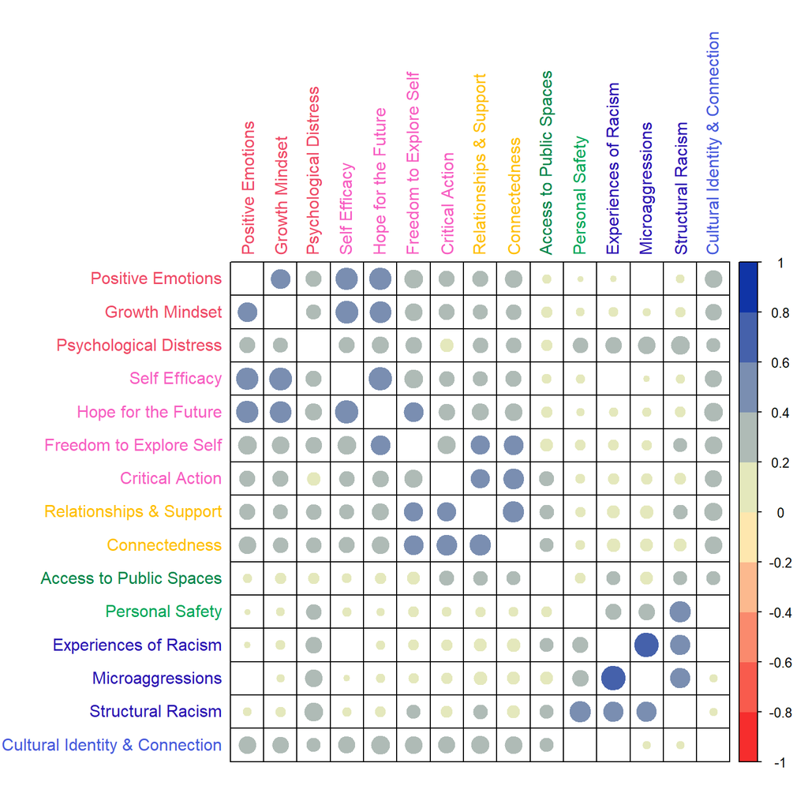

## By Component

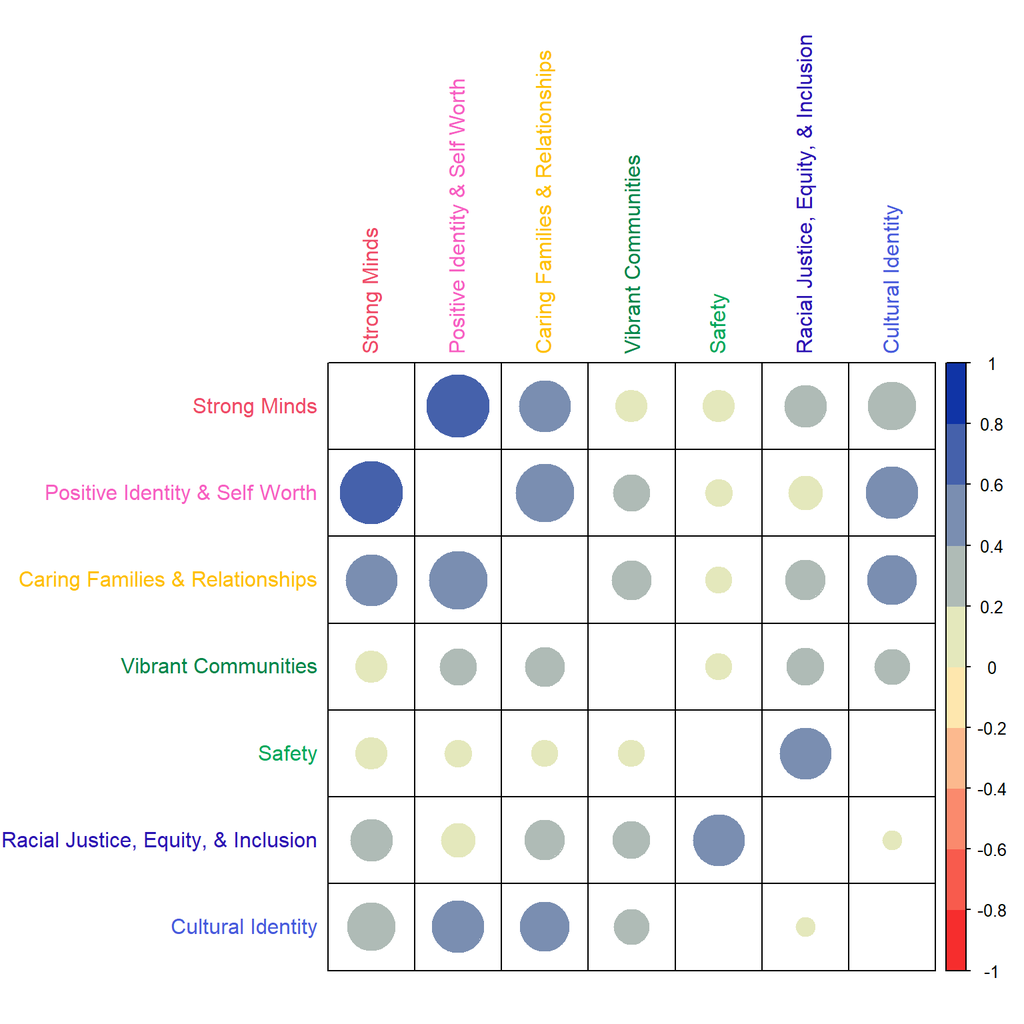

## By Demographics

### Race by Subcomponents

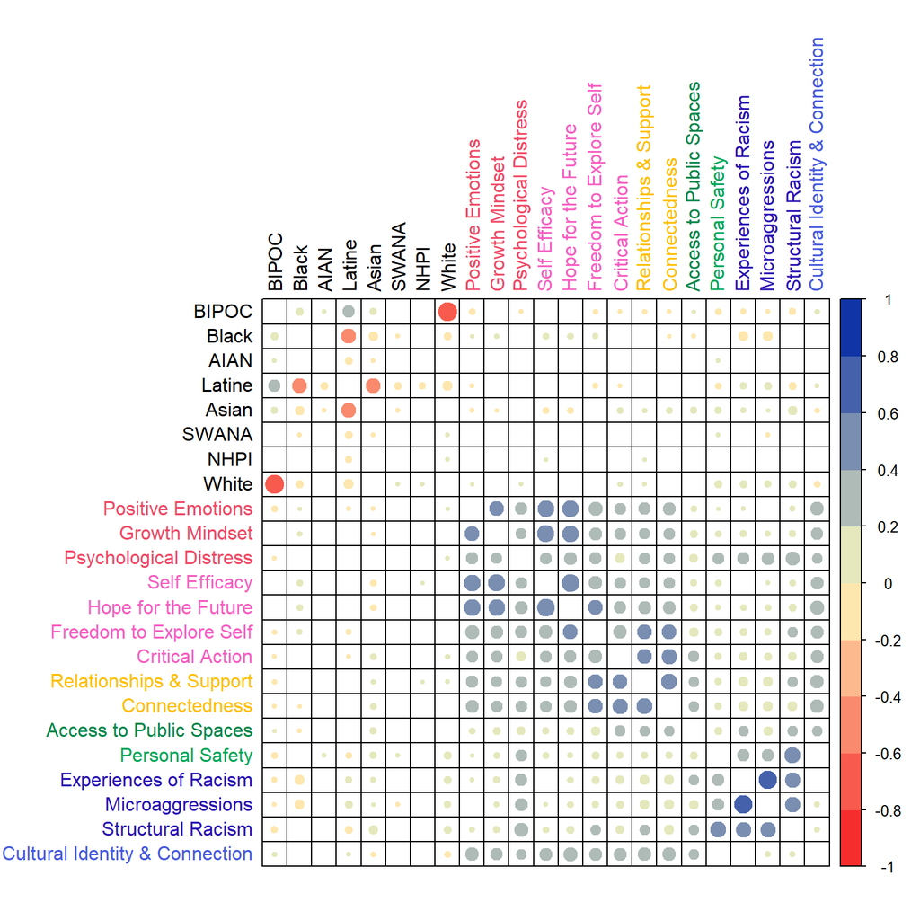

### Race by Components

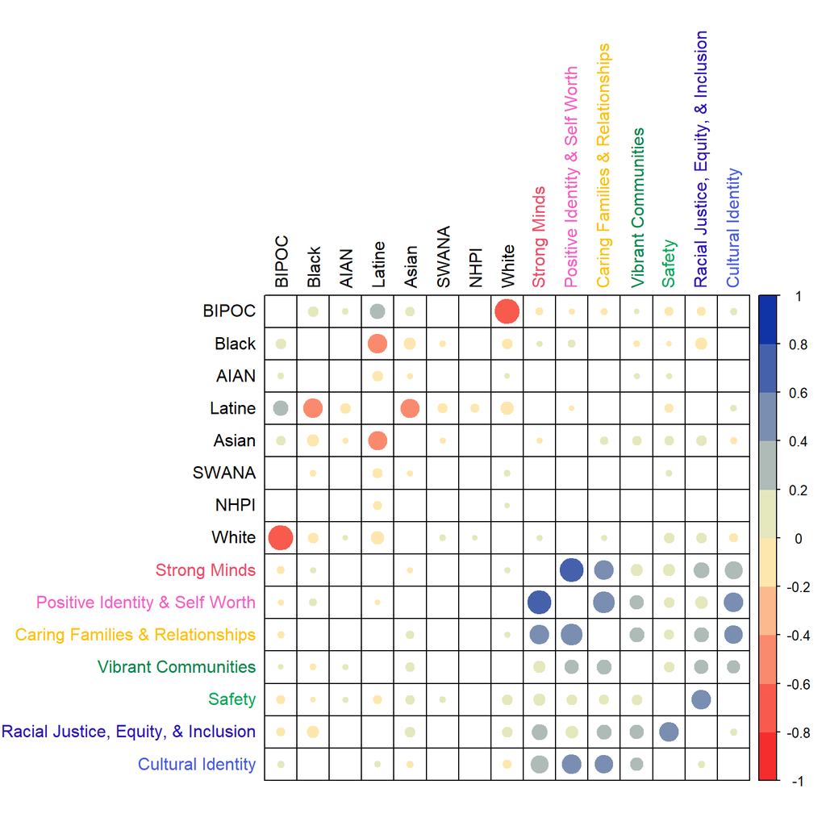

### Other Demographics by Subcomponents

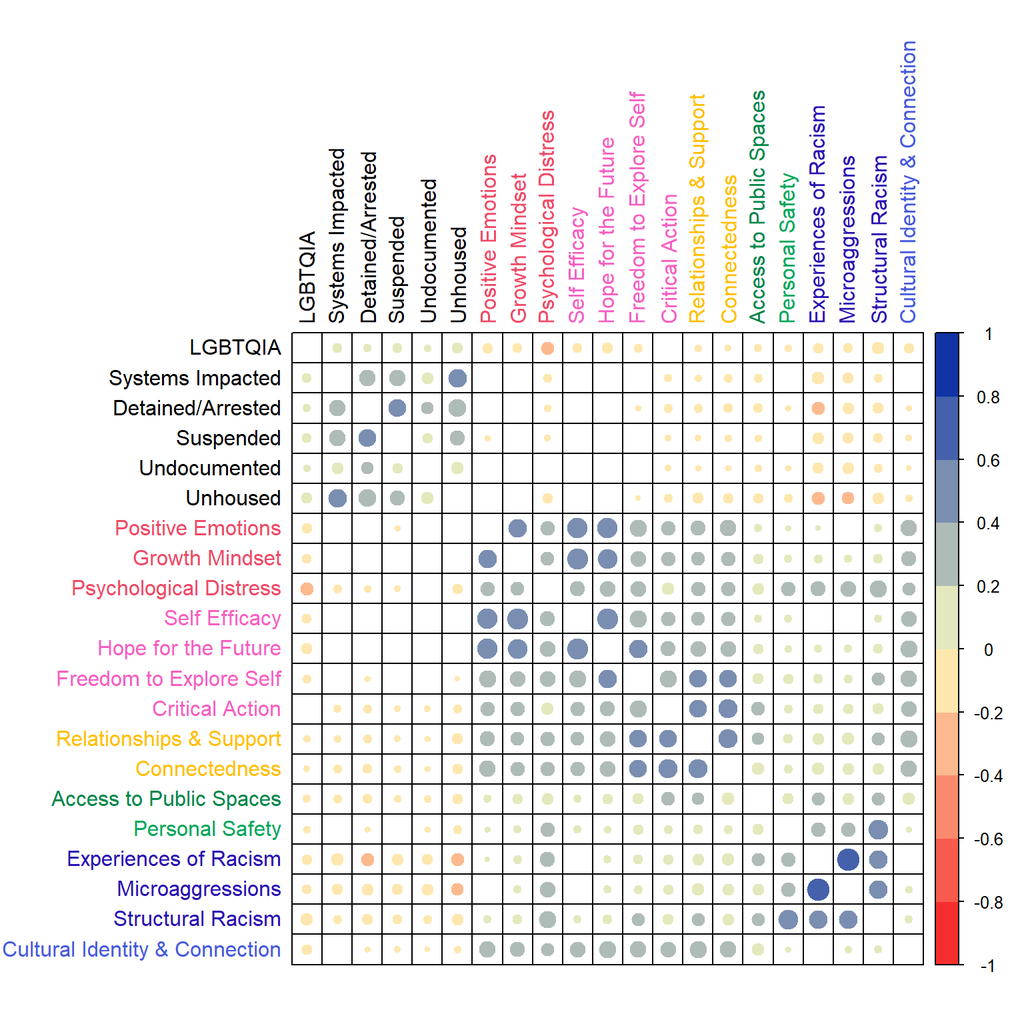

### Other Demographics by Components

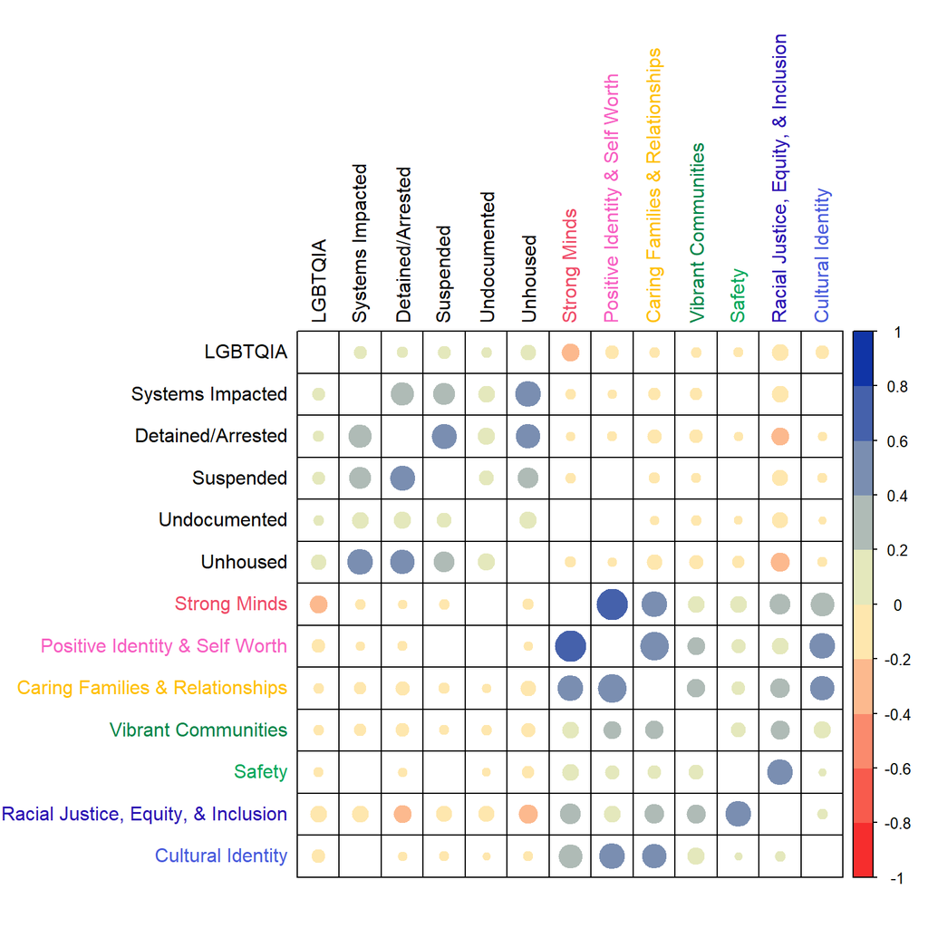